# Treatment Effects in Staggered Adoption Designs with Non-Parallel Trends

Brantly Callaway

University of Georgia

Emmanuel Tsyawo

University of Alabama

September 24, 2025

## Introduction

$\newcommand{\E}{\mathbb{E}} \newcommand{\E}{\mathbb{E}} \newcommand{\var}{\mathrm{var}} \newcommand{\cov}{\mathrm{cov}} \newcommand{\Var}{\mathrm{var}} \newcommand{\Cov}{\mathrm{cov}} \newcommand{\Corr}{\mathrm{corr}} \newcommand{\corr}{\mathrm{corr}} \newcommand{\L}{\mathrm{L}} \renewcommand{\P}{\mathrm{P}} \newcommand{\independent}{{\perp\!\!\!\perp}} \newcommand{\indicator}[1]{ \mathbf{1}\{#1\} } \newcommand{\T}{T} \newcommand{\ATT}{\text{ATT}}$ Setting of the paper: Panel data causal inference with

- Binary Treatment
- Fixed-$T$
- Multiple possible comparison groups
  - Staggered treatment adoption
  - Multiple comparison states

Main idea: Exploit having access to “extra” periods and comparison groups to substantially weaken auxiliary assumptions (like parallel trends) that are common in this setting

Running Example: Causal effect of $\underbrace{\textrm{job displacement}}_{\textrm{treatment}}$ on $\underbrace{\textrm{earnings}}_{\textrm{outcome}}$

## Outline of the Talk

1. Motivation

2. Identification

3. Application

# Motivation

## Research Design

Research Design: The setting that the researcher will use to estimate causal effects.

Staggered adoption research design:

1. Multiple periods of data
2. Some pre-treatment data for all units
3. Some units become treated while other units remain untreated

This research design is a key distinguishing feature of modern approaches to panel data causal inference relative to traditional panel data models

- It allows for explicit comparisons between treated units and a comparison group.
- It also explains why the methods we consider today are often grouped among quasi-experimental methods such as IV or RD.

## Identification Strategy

Identification Strategy: A target parameter and set of assumptions that allow the researcher to recover the target parameter ➡

## Comparison to IV and RD

IV and RD are closely connected to natural experiments where the assignment of treatment, though not controlled by the researcher, is (usually locally) randomly assigned.

- draft lottery numbers
- cutoff scores on standardized tests

This implies that

- The research design is simply to exploit the natural experiment
- The identification strategy formalizes the natural experiment
  - Exclusion restriction, exogeneity, monotonicity are (almost) properties of the natural experiment
  - There are not really alternative identification for the same research design

## Panel Data Natural Experiments?

Panel data causal inference methods are often used in settings where there is no explicit natural experiment:

- e.g., some locations implement a policy while others do not

This implies that

- Auxiliary assumptions, such as parallel trends, play an important role in the identification strategy
  - These assumptions are not implied by the research design
  - One could imagine making alternative auxiliary assumptions instead
  - Panel data causal inference methods are often referred to “model-based” as assumptions like parallel trends effectively involve a model for the outcome.
- (Probably) less credible than methods that are based on natural experiments

## Why Are Panel Data Approaches Popular?

1. Availability

2. Allow for within-unit comparisons

3. Allow for selection on unobservables

4. Pre-testing [Event Study Plot]

## Our Paper

- Keep the nice features of panel approaches to causal inference, but weaken auxiliary assumptions
- Try to adapt to complexity of trend differences across groups in pre-treatment periods
- Retain ability to falsify approach in pre-treatment periods

# Identification

## Staggered Treatment Adoption

Treatment timing can vary across units, but once a unit becomes treated, it remains treated in subsequent periods

Many of the insights of recent work on DiD have been in the context of staggered treatment adoption

- de Chaisemartin and D’Haultfoeuille (2020), Goodman-Bacon (2021), Callaway and Sant’Anna (2021), Sun and Abraham (2021), Marcus and Sant’Anna (2021), among others
- These papers treat staggered treatment adoption as a nuisance, and
  - Show limitations of two-way fixed regressions for implementing DiD identification strategies
  - Provide alternative estimation strategies

In the current paper, we will exploit staggered treatment adoption in order to identify causal effect parameters

## Notation / Data / Setup

Observed data: $\{Y_{i1}, Y_{i2}, \ldots Y_{i\T}, D_{i1}, D_{i2}, \ldots, D_{i\T}\}_{i=1}^n$

- $\T$ time periods
- No one treated in the first time period (i.e., $D_{i1} = 0$)
- Staggered treatment adoption: for $t=2,\ldots,\T$, $D_{it-1} = 1 \implies D_{it}=1$.
- A unit’s group $G_i$ is the time period when it becomes treated.
  - By convention, set $G_i = \infty$ for never-treated units
- Potential outcomes: $Y_{it}(g)$, $Y_{it}(0)$ is untreated potential outcome
- Observed outcomes: $Y_{it} = Y_{it}(G_i)$
- No anticipation: For $t < G_i$, $Y_{it} = Y_{it}(0)$

Setup is exactly the same as DiD with staggered treatment adoption!

## Target Parameters

Following Callaway and Sant’Anna (2021), we target group-time average treatment effects:
$$\begin{align*}
ATT(g,t) = \E[Y_t(g) - Y_t(0) | G=g]
\end{align*}$$

$ATT(g,t)$ is the average treatment effect for group $g$ in time period $t$

Group-time average treatment effects are the natural building block for other common target parameters in DiD applications such as event studies or an overall $ATT$ (see Callaway and Sant’Anna (2021) for more details)

## Latent Unconfoundedness

Latent Unconfoundedness

$$Y_{it}(0) \independent G_i | \xi_i$$

See Gobillon and Magnac (2016);Gardner (2020);Arkhangelsky and Imbens (2022);Callaway and Karami (2023), among others

Intuition:

- If we could observe $\xi_i$, then we could estimate causal effects by comparing treated and untreated units with the same $\xi_i$

## Operationalizing Latent Unconfoundedness

Latent unconfoundedness implies that we can write

$$Y_{it}(0) = h_t(\xi_i) + e_{it} \quad \textrm{where} \quad \E[e_{it} | \xi_i, G_i] = 0$$

This is a hard model to make progress with because $h_t(\cdot)$ is completely unrestricted, but often we think of approximations

$$h_t(\xi_i) = \theta_t + \xi_i \qquad \implies \text{DiD}$$

## More General Approximations to $h_t(\xi_i)$

We will go for more general approximations to $h_t(\xi_i)$, for $\xi_i = (\eta_i', \lambda_i')'$:

$$h_t(\xi_i) = \theta_t + \eta_i + \lambda_i'F_t + r_{it}$$

where $r_{it}$ is approximation error.

Terminology:

- $\lambda_i$ is often referred to as “factor loading”
- $F_t$ is often referred to as a “factor”

## More General Approximations to $h_t(\xi_i)$

We will go for more general approximations to $h_t(\xi_i)$, for $\xi_i = (\eta_i', \lambda_i')'$:

$$h_t(\xi_i) = \theta_t + \eta_i + \lambda_i'F_t + r_{it}$$

where $r_{it}$ is approximation error.

Terminology:

In our context, though, it makes sense to interpret these as

- $\lambda_i$ unobserved heterogeneity (e.g., individual’s unobserved “ability”)
- $F_t$ the time-varying “return” unobserved heterogeneity (e.g., return to “ability”)

[Unit-specific linear trends] [IFE and violations of parallel trends]

## More General Approximations to $h_t(\xi_i)$

We will go for more general approximations to $h_t(\xi_i)$, for $\xi_i = (\eta_i', \lambda_i')'$:

$$h_t(\xi_i) = \theta_t + \eta_i + \lambda_i'F_t + r_{it}$$

where $r_{it}$ is approximation error.

Some comments:

🧩 In a setting with fixed-$T$ and fixed number of comparison groups, there are going to be limits on how complex we can make approximation

🧩 The dimension of $\xi_i$ could be fairly large

## More General Approximations to $h_t(\xi_i)$

We will go for more general approximations to $h_t(\xi_i)$, for $\xi_i = (\eta_i', \lambda_i')'$:

$$h_t(\xi_i) = \theta_t + \eta_i + \lambda_i'F_t + r_{it}$$

where $r_{it}$ is approximation error.

Some comments:

💡 The dimension of $\eta_i$ can be high without much cost

💡 We do not necessarily need to “control for” every component of $\lambda_i$ that affects the outcome, just the ones that are imbalanced across groups

## Identification in a Particular Case

Particular Case: $\T=4$ and 3 groups: 3, 4, $\infty$

IFE Model:

Target:

$Y_{it}(0) = \theta_t + \eta_i + \lambda_i F_t + e_{it}$

$ATT(g=3,t=3) = \E[\Delta Y_3 | G=3] - \underbrace{\color{#BA0C2F}{\E[\Delta Y_3(0) | G=3]}}_{\textrm{have to figure out}}$

Using quasi-differencing argument, can show that

$$\Delta Y_{i3}(0) = \theta_t^* + F_3^* \Delta Y_{i2}(0) + v_{i3}$$

where $\theta_3^*$ and $F_3^*$ are functions of the parameters $\theta_t$ and $F_t$, and $v_{i3}$ is a function of $e_{it}$.

[Explanation]

## Identifying $ATT(g=3,t=3)$

Now (momentarily) suppose that we (somehow) know $\theta_3^*$ and $F_3^*$. Then,

$$\begin{align*}
\color{#BA0C2F}{\E[\Delta Y_3(0) | G=3]} = \theta_3^* + F_3^* \underbrace{\E[\Delta Y_2(0) | G = 3]}_{\textrm{identified}} + \underbrace{\E[v_3|G=3]}_{=0}
\end{align*}$$

$\implies$ this term is identified; hence, we can recover $ATT(3,3)$.

## How can we recover $\theta_3^*$ and $F_3^*$?

Recall:

$$\Delta Y_{i3}(0) = \theta_3^* + F_3^* \Delta Y_{i2}(0) + \underbrace{\Delta e_{i3} - \frac{\Delta F_3}{\Delta F_2} \Delta e_{i2}}_{=: v_{i3}}$$

Some issues:

📝 Expression involves untreated potential outcomes through period 3 $\implies$ Only groups 4 and $\infty$ are useful for recovering $\theta_3^*$ and $F_3^*$

🤔 $\Delta Y_{i2}(0)$ is correlated with $v_{i3}$ by construction $\implies$ We need some exogenous variation to recover the parameters

## Existing Ideas in the Literature

There are a number of different ideas here:

- Make additional assumptions ruling out serial correlation in $e_{it}$ $\implies$ can use lags of outcomes as instruments (Imbens, Kallus, and Mao (2021)):
  - But this is seen as a strong assumption in many applications (Bertrand, Duflo, and Mullainathan (2004))
- Alternatively can introduce covariates and make auxiliary assumptions about them (Callaway and Karami (2023);Brown and Butts (2023);Brown, Butts, and Westerlund (2023))
- However, it turns out that, with staggered treatment adoption, you can recover $ATT(3,3)$ essentially for free

## Our Approach

In particular, notice that, given that we have two distinct untreated groups in period 3: group 4 and group $\infty$, then we have two moment conditions:

$$\begin{align*}
\E[\Delta Y_3(0) | G=4] &= \theta_3^* + F_3^* \E[\Delta Y_2(0) | G=4] \\
\E[\Delta Y_3(0) | G=\infty] &= \theta_3^* + F_3^* \E[\Delta Y_2(0) | G=\infty] \\
\end{align*}$$

We can solve these for $\theta_3^*$ and $F_3^*$:
$$\begin{align*}
F_3^* &= \frac{\E[\Delta Y_3|G=\infty] - \E[\Delta Y_3|G=4]}{\E[\Delta Y_2|G=\infty] - \E[\Delta Y_2|G=4]} \\[10pt]
\theta_3^* &= \E[\Delta Y_3 | G=4] - F_3^* \E[\Delta Y_2 | G=4]
\end{align*}$$

$\implies$ we can recover $ATT(3,3)$.

This strategy amounts to using “group” as an instrument for $\Delta Y_{i2}(0)$.

## Additional Details about Identification

Condition 1: Relevance $\quad \E[\Delta Y_2(0) | G=4] \neq \E[\Delta Y_2(0) | G=\infty]$

For relevance to hold, the following two “more primitive” conditions both need to hold

- $\E[\lambda | G=4] \neq \E[\lambda | G = \infty]$
- $F_2 \neq F_1$

Otherwise, $G = 4$ and $G = \infty$ have the same trend between the first two periods.

- $\implies$ $F_3^*$ is not identified

## Additional Details about Identification

Condition 2: Exogeneity

Group is uncorrelated with $r_{it} + e_{it}$

- This would be violated if, for example, the model for untreated potential outcomes should include two factors instead of one.
- i.e., our approximation to $h_t(\xi_i)$ is not good enough

## Additional Details about Identification

Condition 2: Exogeneity

Can’t directly test exogeneity, but a lot of the DiD infrastructure carries over

- For DiD, can “pre-test” parallel trends if have more than 1 pre-period
- For our approach, we need 2 pre-treatment periods to identify $ATT(g,t)$, but if have more pre-treatment periods then we can pre-test
  - e.g., if we have 3 pre-treatment periods, then non-zero pseudo-ATT’s in pre-treatment periods suggest that the exogeneity condition is violated.

## General Case with More Periods and Groups

There are additional complications for making this work in realistic applications:

1. How do we know how many IFEs there are?

2. Does having more groups/periods help?

3. Are there testable implications in general settings?

## A Picture of the Previous Case

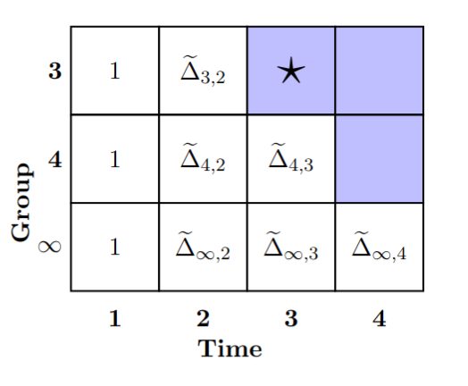

- where $\widetilde{\Delta}_{g,t} = \E[\Delta Y_t(0) | G=g]$
- if we know $\Huge \star$ then we can recover $ATT(3,3)$

## A Picture of the Previous Case

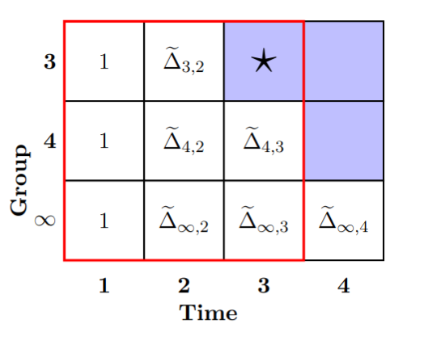

if has reduced rank, then we can fill in $\Huge \star$ and recover $ATT(3,3)$

## A Picture of the Previous Case

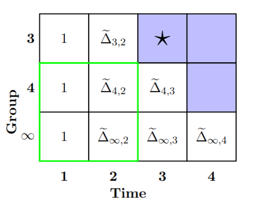

Check rank of and assume that rank( ) = rank( ) ➡️

## A Picture of the Previous Case

Case 1: If rank( ) = 2

- Suggests model with 1 IFE
- This is exactly the rank condition discussed before!
- No testable implications

Case 2: If rank( ) = 1

- Suggests model with 0 IFEs(i.e., parallel trends)
- This corresponds to failure of rank condition from before
- Testable implications ➡️

## A Picture of the Previous Case

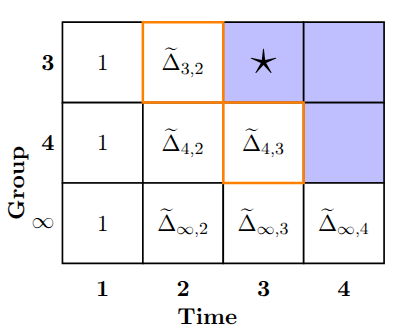

- If rank( ) = rank( ) = 1, then we can observe and also fill it in from
- You can see these in pre-treatment periods in a group-specifc event studies

## More General Case with More Periods and Groups

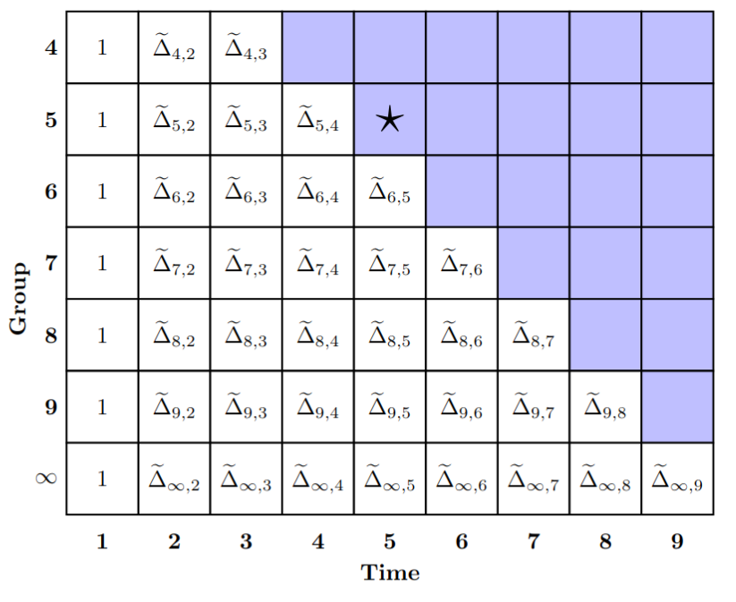

## More General Case with More Periods and Groups

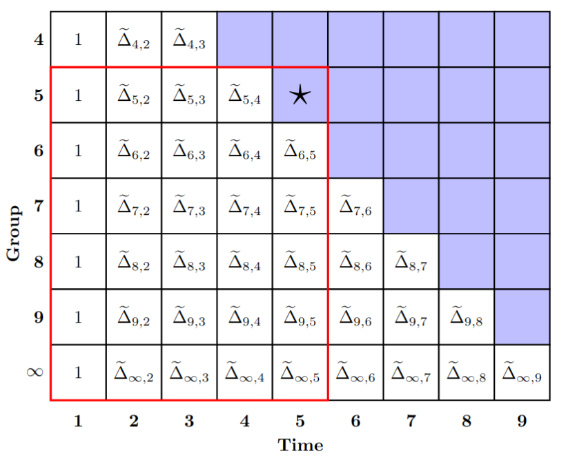

if has reduced rank, then we can fill in $\Huge \star$ and recover $ATT(5,5)$

## More General Case with More Periods and Groups

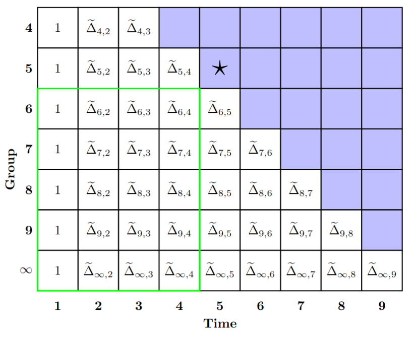

Check rank of and assume that rank( ) = rank( ) ➡️

## More General Case with More Periods and Groups

Case 1: If rank( ) = 4 $\implies$ 3 IFEs

Case 2: If rank( ) = 3 $\implies$ 2 IFEs

Case 3: If rank( ) = 2 $\implies$ 1 IFE

Case 4: If rank( ) = 1 $\implies$ 0 IFEs (i.e., parallel trends)

## More General Case with More Periods and Groups

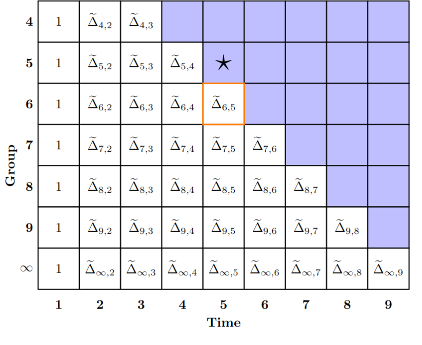

Testable implications when rank( ) = rank( ) = 4

## More General Case with More Periods and Groups

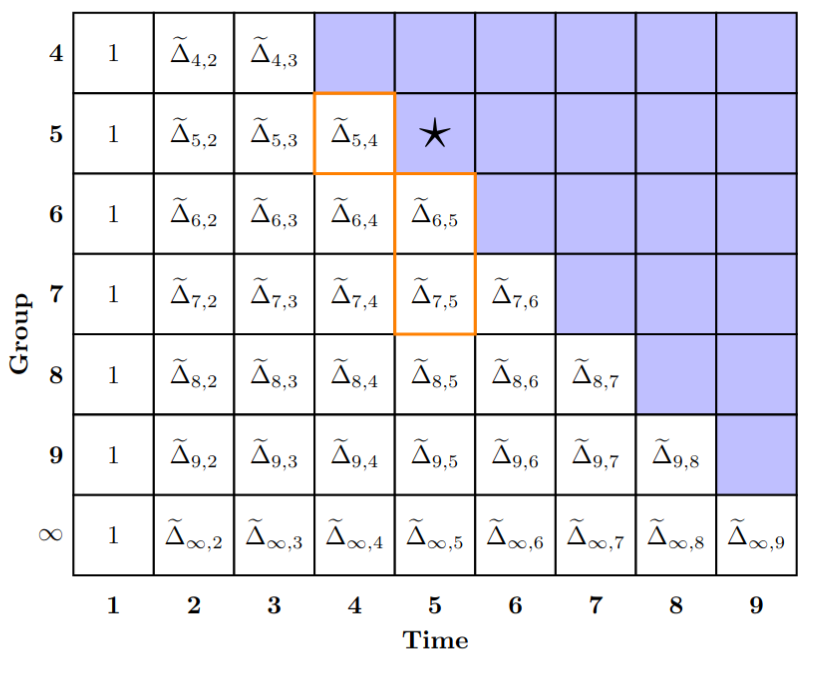

Testable implications when rank( ) = rank( ) = 3

## More General Case with More Periods and Groups

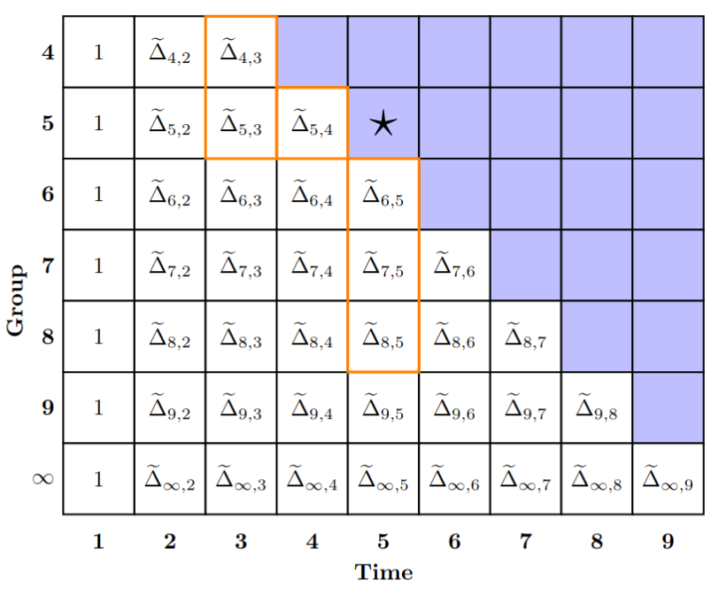

Testable implications when rank( ) = rank( ) = 2

## Identifying Other ATT(g,t)’s

Intuition:

- Very similar to previous case
- In earlier periods, the complexity of trends we can accommodate is limited by the number of pre-treatment periods
- In later periods, the complexity of trends we can accommodate is limited by the number of available comparison groups
  - Though still have testable implications

Examples:

- ATT(g=4,t=4)
- ATT(g=5,t=6)
- ATT(g=9,t=9)

## Discussion

- Relative to other approaches to dealing with IFEs:
  - We do not need a large number of periods or extra auxiliary assumptions
  - Only need there to be staggered treatment adoption (or other source of comparison groups)
- Our approach adapts to the complexity of trend differences across groups in pre-treatment periods
- Like DiD, we are always going to give an estimate and, often, we will have extra information to falsify our approach
- We have talked about IFE models, but exploiting additional comparison groups seems like a good idea more generally
  - There are other types of models that need extra moment conditions (e.g., dynamic panel data model for $Y_{it}(0)$), could use the same sort of idea there

## Estimation

If the number of interactive fixed effects is known

- Two-step estimation procedure where we estimate the parameters of the IFE model in the first step (e.g., $\theta_3^*$ and $F_3^*$) and then plug these into a second step estimator for $ATT(g,t)$.

If the number of interactive fixed effects is unknown

- Additionally need to estimate rank( ) and account for the fact that this is estimated in the theory
- In progress…

# Application

## Setup

- Use county-level data from 1998-2007 during a period where the federal minimum wage was flat
- Exploit minimum wage changes across states
  - Any state that increases their minimum wage above the federal minimum wage will be considered as treated
  - Allow for one year of “anticipation” (this only affects estimates in post-treatment periods)
- Interested in the effect of the minimum wage on teen employment
- We’ll also make a number of simplifications:
  - not worry much about issues like clustered standard errors
  - not worry about variation in the amount of the minimum wage change (or whether it keeps changing) across states

## DiD Estimates

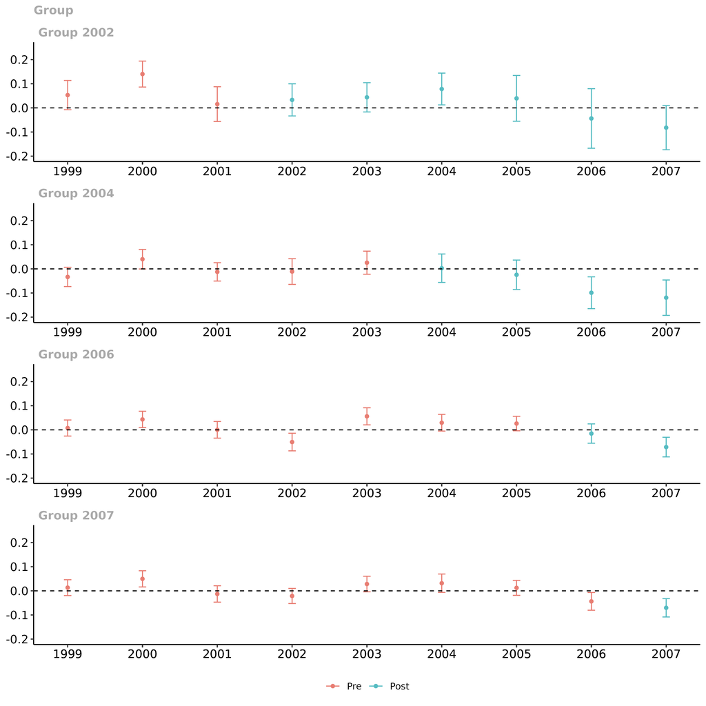

## IFE Clarifications

- The next set of results include one interactive fixed effect
- Additional Comments:
  - Because of anticipation, we can only estimate effects up to 2005 (after that $G=2007$ is no longer a valid comparison group)
  - We also lose some estimates in early periods because those are needed in the quasi-differencing steps
  - No estimates for $G=2007$ at all because not enough valid comparison groups

## IFE Results

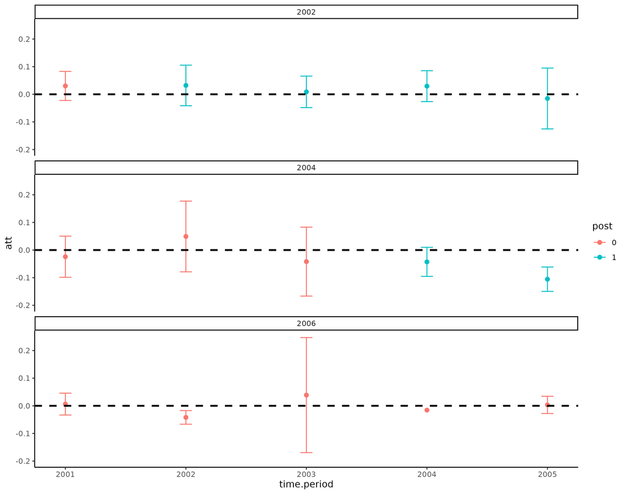

## Conclusion

Comments welcome: `brantly.callaway@uga.edu`

Code: `staggered_ife2` function in `ife` package in R, available at github.com/bcallaway11/ife

# Appendix

## References

Arkhangelsky, Dmitry, Susan Athey, David A Hirshberg, Guido W Imbens, and Stefan Wager. 2021. “Synthetic Difference-in-Differences.” *American Economic Review* 111 (12): 4088–118.

Arkhangelsky, Dmitry, and Guido W Imbens. 2022. “Doubly Robust Identification for Causal Panel Data Models.” *The Econometrics Journal* 25 (3): 649–74.

Athey, Susan, Mohsen Bayati, Nikolay Doudchenko, Guido Imbens, and Khashayar Khosravi. 2021. “Matrix Completion Methods for Causal Panel Data Models.” *Journal of the American Statistical Association*, 1–15.

Bertrand, Marianne, Esther Duflo, and Sendhil Mullainathan. 2004. “How Much Should We Trust Differences-in-Differences Estimates?” *The Quarterly Journal of Economics* 119 (1): 249–75.

Brown, Nicholas, and Kyle Butts. 2023. “Dynamic Treatment Effect Estimation with Interactive Fixed Effects and Short Panels.”

Brown, Nicholas, Kyle Butts, and Joakim Westerlund. 2023. “Simple Difference-in-Differences Estimation in Fixed-t Panels.”

Callaway, Brantly, and Sonia Karami. 2023. “Treatment Effects in Interactive Fixed Effects Models with a Small Number of Time Periods.” *Journal of Econometrics* 233 (1): 184–208.

Callaway, Brantly, and Pedro HC Sant’Anna. 2021. “Difference-in-Differences with Multiple Time Periods.” *Journal of Econometrics* 225 (2): 200–230.

de Chaisemartin, Clement, and Xavier D’Haultfoeuille. 2020. “Two-Way Fixed Effects Estimators with Heterogeneous Treatment Effects.” *American Economic Review* 110 (9): 2964–96.

Gardner, John. 2020. “Identification and Estimation of Average Causal Effects When Treatment Status Is Ignorable Within Unobserved Strata.” *Econometric Reviews* 39 (10): 1014–41.

Gobillon, Laurent, and Thierry Magnac. 2016. “Regional Policy Evaluation: Interactive Fixed Effects and Synthetic Controls.” *Review of Economics and Statistics* 98 (3): 535–51.

Goodman-Bacon, Andrew. 2021. “Difference-in-Differences with Variation in Treatment Timing.” *Journal of Econometrics* 225 (2): 254–77.

Imbens, Guido, Nathan Kallus, and Xiaojie Mao. 2021. “Controlling for Unmeasured Confounding in Panel Data Using Minimal Bridge Functions: From Two-Way Fixed Effects to Factor Models.”

Marcus, Michelle, and Pedro HC Sant’Anna. 2021. “The Role of Parallel Trends in Event Study Settings: An Application to Environmental Economics.” *Journal of the Association of Environmental and Resource Economists* 8 (2): 235–75.

Sun, Liyang, and Sarah Abraham. 2021. “Estimating Dynamic Treatment Effects in Event Studies with Heterogeneous Treatment Effects.” *Journal of Econometrics* 225 (2): 175–99.

Xu, Yiqing. 2017. “Generalized Synthetic Control Method: Causal Inference with Interactive Fixed Effects Models.” *Political Analysis* 25 (1): 57–76.

## Event Study Plot

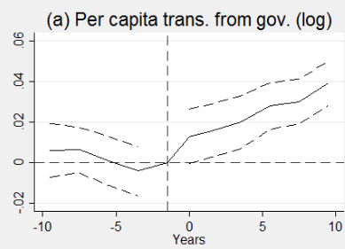

Deryugina (2017)

[Back]

## IFE Models and Unit-Specific Linear Trends

IFE model for untreated potential outcomes:
$$\begin{align*}
Y_{it}(0) = \theta_t + \eta_i + \lambda_i F_t + e_{it}
\end{align*}$$

Special Case: $F_t = t$ $\implies$ unit-specific linear trends

[Back]

## IFE & Violations of Parallel Trends

Interactive fixed effects models allow for violations of parallel trends:

$$\begin{aligned}
Y_{it}(0) &= \theta_t + \eta_i + \lambda_i F_t + e_{it} \\
\end{aligned}$$

$$\implies \E[\Delta Y_{t}(0) | D = d] = \Delta \theta_t + \E[\lambda|D=d]\Delta F_t$$

which can vary across groups.

Example: If $\lambda_i$ is “ability” and $F_t$ is increasing over time, then (even in the absence of the treatment) groups with higher mean “ability” will tend to increase outcomes more over time than less skilled groups

[Back]

## Quasi-Differencing Explanation

Particular Case: $\T=4$ and 3 groups: 3, 4, $\infty$

$$Y_{it}(0) = \theta_t + \eta_i + \lambda_i F_t + e_{it}$$

In this case, given the IFE model for untreated potential outcomes, we have:
$$\begin{align*}
\Delta Y_{i3}(0) &= \Delta \theta_3 + \lambda_i \Delta F_3 + \Delta e_{i3} \\
\Delta Y_{i2}(0) &= \Delta \theta_2 + \lambda_i \Delta F_2 + \Delta e_{i2} \\
\end{align*}$$

The last equation implies that
$$\begin{align*}
\lambda_i = \Delta F_2^{-1}\Big( \Delta Y_{i2}(0) - \Delta \theta_2 - \Delta e_{i2} \Big)
\end{align*}$$
Plugging this back into the first equation (and combining terms), we have $\rightarrow$

## Quasi-Differencing Explanation

Particular Case: $\T=4$ and 3 groups: 3, 4, $\infty$

From last slide, combining terms we have that

$$\begin{align*}
\Delta Y_{i3}(0) = \underbrace{\Big(\Delta \theta_3 - \frac{\Delta F_3}{\Delta F_2} \Delta \theta_2 \Big)}_{=: \theta_3^*} + \underbrace{\frac{\Delta F_3}{\Delta F_2}}_{=: F_3^*} \Delta Y_{i2}(0) + \underbrace{\Delta e_{i3} - \frac{\Delta F_3}{\Delta F_2} \Delta e_{i2}}_{=: v_{i3}}
\end{align*}$$

[Back]

## ATT(g=5,t=6)

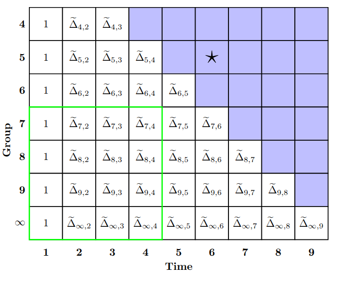

Insight: Similar to previous case except there are fewer “available” comparison groups for later time periods. [Back]

## ATT(g=4,t=4)

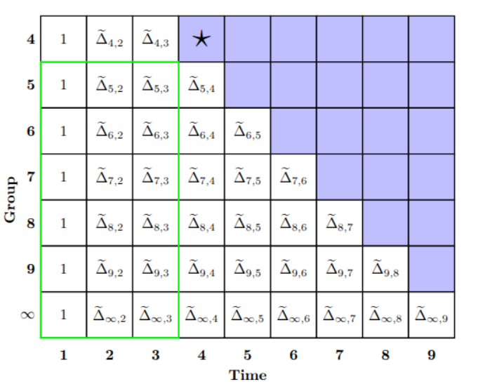

Insight: Fewer available pre-treatment periods limit the number of IFEs we can accommodate, though there are testable implications here (due to the large number of available comparison groups). [Back]

## ATT(g=9,t=9)

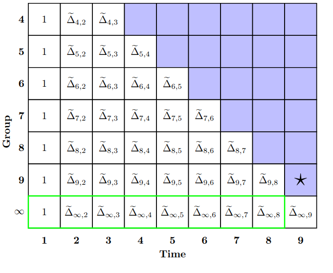

Insight: Only one comparison group available in period 9, so we can only accommodate 0 IFEs (i.e., parallel trends), though there are testable implications (due to the large number of pre-treatment periods). [Back]

## General Case - Setup

Interactive fixed effects for untreated potential outcomes:

$$Y_{it}(0) = \theta_t + \eta_i + \lambda_i' F_t + e_{it}$$
where $\lambda_i$ and $F_t$ are $R$ dimensional vectors.

Assume: Unconfoundedness conditional on unobserved heterogeneity (i.e., this implies “groups” can be used as instruments):

$$\E[Y_{t}(0) |\eta, \lambda, G] = \E[Y_{t}(0) |\eta, \lambda] \quad \text{a.s.}$$

An implication of both conditions above is that

$$\E[e_t |\eta, \lambda, G] = 0$$

which we use below as a source of moment conditions to identify parameters from the interactive fixed effects model.

## General Case - Identification

Similar to earlier case:

$$\begin{aligned}
ATT(g,t) = \E[Y_t - Y_{g-1} | G=g] - \underbrace{\E[Y_t(0) - Y_{g-1}(0) | G=g]}_{\textrm{need to figure out}} \\
\end{aligned}$$

## General Case - Identification

Using similar differencing arguments as before, one can show:

$$Y_{it}(0) - Y_{ig-1}(0) = \theta^*(g,t) + \widetilde{\Delta Y}_i^{pre(g)}(0)'F^*(g,t) + v_i(g,t)$$

where

- $\widetilde{\Delta Y}_i^{pre(g)}(0)$ is an $R$-dimensional vector of transformations of pre-treatment outcomes,
- $\theta^*(g,t)$ and $F^*(g,t)$ are transformations of time fixed effects and factors,
- $v_i(g,t)$ involves transformations of $e_{it}$.

## General Case - Identification

Using similar differencing arguments as before, one can show:

$$Y_{it}(0) - Y_{ig-1}(0) = \theta^*(g,t) + \widetilde{\Delta Y}_i^{pre(g)}(0)'F^*(g,t) + v_i(g,t)$$

so that

- $R+1$ parameters to identify
- $\widetilde{\Delta Y}_i^{pre(g)}(0)$ is endogenous by construction
- Can use “groups” as instruments
- Identification is local to groups/periods that meet the following criteria:
  - Group must have at least $R+1$ pre-treatment periods (so quasi-differencing is feasible)
  - Time period must be early enough so that there are enough $(R+1)$ untreated comparison groups.

## General Case - Identification

For $g' \in \mathcal{G}^{comp}(g,t)$, we use moment conditions of the form

$$0 = \E\Big[\indicator{G=g'} v(g,t)\Big]$$

Stacking the above moment conditions, we have that

$$\mathbf{0}_{|\mathcal{G}^{comp}(g,t)|} = \E\left[ \ell^{comp}(g,t) \left\{ \Big( Y_{t} - Y_{g-1}\Big) - \Big(\theta^*(g,t) - {\widetilde{\Delta Y}}^{{pre(g)}^{'}} F^*(g,t) \Big) \right\} \right]$$

where $\ell^{comp}(g,t)$ is a vector of indicators for groups that have not yet been treated by period $t$.

## General Case - Identification

Since we are using groups as IVs, identification hinges on relevance:

$$\textrm{Rank}\Big(\mathbf{\Gamma}(g,t)\Big) = R + 1$$

where

$$\mathbf{\Gamma}(g,t) := \E\left[ \ell^{comp}(g,t) \begin{pmatrix} 1 \\ \widetilde{\Delta Y}^{pre(g)} \end{pmatrix}' \right]$$

As before, you can relate the relevance condition to conditions on $\lambda_i$ and $F_t$.

- Need “enough variation” in $\E[\lambda|G=g']$ among groups in $\mathcal{G}^{comp}(g,t)$.
- Need “enough variation” in $F_t$ across pre-treatment time periods.

[More Details]

## General Case - Identification

**Theorem: Identification**

For some group $g \in \mathcal{G}^\dagger$, and for some time period $t \in \{g, \ldots, t^{max}(g)\}$ where $t^{max}(g)$ is the largest value of $t$ such that $|\mathcal{G}^{comp}(g,t)| \geq R+1$ and under given assumptions,

$$\begin{pmatrix}
\theta^*(g,t) \\ F^*(g,t)
\end{pmatrix} = \Big( \mathbf{\Gamma}(g,t)' \mathbf{W}(g,t) \mathbf{\Gamma}(g,t) \Big)^{-1} \mathbf{\Gamma}(g,t)' \mathbf{W}(g,t) \E[\ell^{comp}(g,t)(Y_{t} - Y_{g-1})]$$

In addition, $ATT(g,t)$ is identified, and it is given by:

$$ATT(g,t) = \E[Y_t(g) - Y_{g-1} | G=g] - \Big( \theta^*(g,t) + F^*(g,t)'\E[\Delta Y^{pre(g)} | G=g] \Big)$$

## Estimation

Estimation proceeds in two steps and is constructive given identification results. The first step is to estimate $\theta^*(g,t)$ and $F^*(g,t)$:

Given a positive definite matrix $\widehat{\mathbf{W}}(g,t)$, the estimator of $\delta^*(g,t)$ is:

$$\widehat{\delta}^*(g,t) = \left( \widehat{\mathbf{\Gamma}}(g,t)' \widehat{\mathbf{W}}(g,t)\widehat{\mathbf{\Gamma}}(g,t) \right)^{-1} \widehat{\mathbf{\Gamma}}(g,t)' \widehat{\mathbf{W}}(g,t) \E_n\big[\ell^{comp}_i(g,t)(Y_{it} - Y_{ig-1})\big]$$

## Estimation

Second step, plug into sample analog of expression for $ATT(g,t)$:

$$\widehat{ATT}(g,t) = \hat{p}_g^{-1} \left\{ \E_n\Big[\indicator{G_i=g}(Y_{it} - Y_{ig-1})\Big] - \E_n\Big[A_i(g)\Big]^\prime \widehat{\delta}^*(g,t) \right\}$$

where

$$A_i(g) := \indicator{G_i=g}\begin{pmatrix}1 \\ \widetilde{\Delta Y}_i^{pre(g)} \end{pmatrix}$$

If you want an event study or overall average treatment effect, can combine estimates across groups and time periods, following the same logic as in Callaway and Sant’Anna (2021).

## Asymptotic Theory

**Theorem: Asymptotic Normality**

Suppose assumptions hold, then for some group $g \in \mathcal{G}^\dagger$, and for some time period $t \in \{g, \ldots, t^{max}(g)\}$ where $t^{max}(g)$ is the largest value of $t$ such that $|\mathcal{G}^{comp}(g,t)| \geq R+1$,

$\widehat{ATT}(g,t)$ is consistent and asymptotically normal, in particular, for each $(g,t)$:

$$\begin{aligned}
\sqrt{n}(\widehat{ATT}(g,t) - ATT(g,t)) &= \frac{1}{\sqrt{n}}\sum_{i=1}^n \psi_{igt} + o_p(1) \\
& \xrightarrow{d} \mathcal{N}(0,\sigma_{gt}^2)
\end{aligned}$$

where $\sigma_{gt}^2 = \E[\psi_{gt}^2]$.

## General Case - Relevance Condition

$$\begin{aligned}
\textrm{Define: } \qquad \mathbf{\Lambda}^{comp}(g,t) := \E\Big[ \ell^{comp}(g,t) \begin{pmatrix} 1 & \lambda' \end{pmatrix} \Big] \quad \textrm{and} \quad
\mathbf{\Delta F}^{pre(g)} := \begin{bmatrix} \Delta F_2' \\ \vdots \\ \Delta F_{g-1}' \end{bmatrix}
\end{aligned}$$

where $\mathbf{\Lambda}^{comp}(g,t)$ is a $|\mathcal{G}^{comp}(g,t)| \times (R+1)$ matrix, and $\mathbf{\Delta F}^{pre(g)}$ is a $(g-2) \times R$ matrix.

**Proposition: Relevance**

The rank condition for identification is equivalent to the following:
$$\textrm{Rank}\Big(\mathbf{\Lambda}^{comp}(g,t)\Big) = R + 1 \quad \textrm{and} \quad \textrm{Rank}\Big(\mathbf{\Delta F}^{pre(g)}\Big) = R$$

[Return]